# R Notebook for sumitomo bacterial functional redundancy

## [6] Assembly from the metacommunity

### [6.1] Definition of function for a given scenario with the metacommunity

At each level of ASV richness for each extinction scenario, preparing 200 replications

```r
sim_extinctionM <- function(com_binarized, KO_binarized, surv_prob = NULL, no_repetition, scenario = "S1") {
  ASV_richnessM <- length(com_binarized[, 1])
  KO_richnessM <- sum(apply(KO_binarized, 2, sum) > 0)
  prob_testM <- prop.table(surv_prob)
  ASVsM <- numeric(21)
  KOs_tempM <- numeric(no_repetition)
  KOs_975 <- numeric(21)
  KOs_025 <- numeric(21)
  KOs_mean <- numeric(21)
  survived_ASVsM <- list()
  s <- ASV_richnessM/20

  #Preparing survival sequences
  for(j in 1:no_repetition) {
    #fully shuffling for the order of survival (the inverse order of extinction)
    survived_ASVsM[[j]] <- sample(1:ASV_richnessM, size = ASV_richnessM, replace = FALSE, prob = prob_testM)
  }

  k <- 1
  ASVsM[k] <- 100
  for(j in 1:no_repetition) {
    KO_survived <- KO_com_binarized[survived_ASVsM[[j]][1:ASVsM[k]], ]
    KO_list_survived <- apply(KO_survived, 2, sum)
    KOs_tempM[j] <- sum(KO_list_survived > 0)
  }
  KOs_mean[k] <- mean(KOs_tempM)  #mean of the replications
  KOs_975[k] <- quantile(KOs_tempM, prob = 0.975) #Upper boundary of 95% confidence interval
  KOs_025[k] <- quantile(KOs_tempM, prob = 0.025) #Lower boundary of 95% confidence interval

  for(k in 2:20) {
    ASVsM[k] <- round(s*(k - 1))
    for(j in 1:no_repetition) {
      KO_survived <- KO_com_binarized[survived_ASVsM[[j]][1:ASVsM[k]], ]
      KO_list_survived <- apply(KO_survived, 2, sum)
      KOs_tempM[j] <- sum(KO_list_survived > 0)
    }
    KOs_mean[k] <- mean(KOs_tempM)  #mean of the replications
    KOs_975[k] <- quantile(KOs_tempM, prob = 0.975) #Upper boundary of 95% confidence interval
    KOs_025[k] <- quantile(KOs_tempM, prob = 0.025) #Lower boundary of 95% confidence interval
  }
  #The case with all ASVs
  k <- 21
  ASVsM[k] <- ASV_richnessM
  KOs_mean[k] <- KO_richnessM
  KOs_975[k] <- KO_richnessM
  KOs_025[k] <- KO_richnessM

  simM <- data.frame(s = rep(scenario, 21), ASV_richness = ASVsM, KOs_mean, KOs_975, KOs_025)
  return(simM)
}
```

### [6.2] Trial

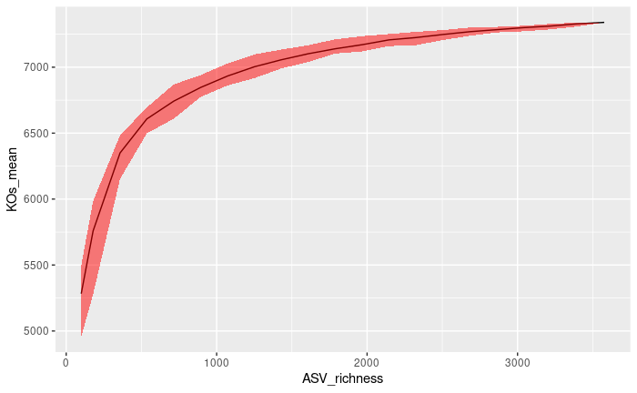

```r
test_randomM <- sim_extinctionM(stand_ASV_com_binarized, KO_com_binarized, surv_prob = survival_rate_mod$F1, no_repetition = 10, scenario = "random")

meta_plot <- ggplot(data = test_randomM) + geom_line(aes(x = ASV_richness, y = KOs_mean))
meta_plot <- meta_plot + geom_ribbon(aes(x = ASV_richness, ymin = KOs_025, ymax = KOs_975), fill = "red", alpha = 0.5)
plot(meta_plot)
```

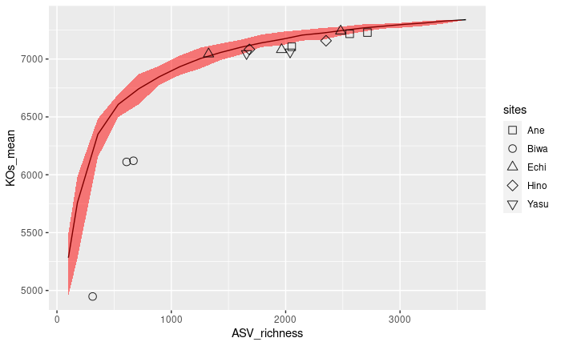

```r
meta_plot <- meta_plot + geom_point(data = richness_MF, aes(x = ASV_richness, y = MF_G, shape = richness_MF$location), size = 3, alpha = 0.9) + labs(shape = "sites") + scale_shape_manual(values = c(0, 1, 2, 5, 6))
plot(meta_plot)
```

### [6.3] Parallel calculations for metacommunity extinctions

```r
meta_sim <- mclapply(1:9, function(i) {
  result_sim <- sim_extinctionM(stand_ASV_com_binarized, KO_com_binarized, surv_prob = survival_rate_mod[, i], no_repetition = 200, scenario = colnames(survival_rate_mod)[i])
  result_sim
}, mc.cores = 9)
```

```r
meta_sim
```

| s | ASV_richness | KOs_mean | KOs_975 | KOs_025 |
| --- | --- | --- | --- | --- |
| random | 100 | 5043.955 | 5627.275 | 4524.800 |
| random | 179 | 5592.045 | 5985.450 | 5167.925 |
| random | 358 | 6141.750 | 6369.300 | 5809.850 |
| random | 536 | 6413.265 | 6608.125 | 6131.525 |
| random | 715 | 6592.965 | 6762.175 | 6369.700 |
| random | 894 | 6720.490 | 6902.025 | 6563.875 |
| random | 1073 | 6816.525 | 6960.050 | 6681.575 |
| random | 1252 | 6894.380 | 7013.375 | 6771.925 |
| random | 1430 | 6959.550 | 7061.175 | 6865.700 |
| random | 1609 | 7017.820 | 7106.050 | 6924.950 |

[output cut: 11 more lines]

| s | ASV_richness | KOs_mean | KOs_975 | KOs_025 |
| --- | --- | --- | --- | --- |
| F1 | 100 | 5335.570 | 5746.475 | 4794.750 |
| F1 | 179 | 5814.085 | 6114.150 | 5366.700 |
| F1 | 358 | 6313.125 | 6494.275 | 6063.225 |
| F1 | 536 | 6558.450 | 6678.500 | 6394.875 |
| F1 | 715 | 6713.725 | 6833.100 | 6570.700 |
| F1 | 894 | 6827.450 | 6952.100 | 6702.825 |
| F1 | 1073 | 6919.010 | 7027.050 | 6812.850 |
| F1 | 1252 | 6992.015 | 7086.000 | 6899.950 |
| F1 | 1430 | 7048.145 | 7122.100 | 6942.775 |
| F1 | 1609 | 7098.160 | 7166.100 | 7009.950 |

[output cut: 11 more lines]

| s | ASV_richness | KOs_mean | KOs_975 | KOs_025 |
| --- | --- | --- | --- | --- |
| F2 | 100 | 4774.790 | 5338.025 | 4350.850 |
| F2 | 179 | 5320.040 | 5796.800 | 4855.775 |
| F2 | 358 | 5886.940 | 6175.550 | 5550.525 |
| F2 | 536 | 6181.100 | 6409.000 | 5861.725 |
| F2 | 715 | 6381.050 | 6575.850 | 6128.725 |
| F2 | 894 | 6535.665 | 6711.075 | 6273.800 |
| F2 | 1073 | 6645.420 | 6818.000 | 6438.750 |
| F2 | 1252 | 6735.935 | 6876.125 | 6527.000 |
| F2 | 1430 | 6810.685 | 6932.200 | 6640.800 |
| F2 | 1609 | 6880.515 | 6988.050 | 6746.850 |

[output cut: 11 more lines]

| s | ASV_richness | KOs_mean | KOs_975 | KOs_025 |
| --- | --- | --- | --- | --- |
| F3 | 100 | 5246.955 | 5744.275 | 4708.875 |
| F3 | 179 | 5733.595 | 6058.200 | 5279.975 |
| F3 | 358 | 6264.675 | 6473.600 | 6006.675 |
| F3 | 536 | 6514.795 | 6684.225 | 6311.825 |
| F3 | 715 | 6675.395 | 6814.025 | 6519.775 |
| F3 | 894 | 6789.595 | 6914.025 | 6657.775 |
| F3 | 1073 | 6882.380 | 6989.025 | 6753.925 |
| F3 | 1252 | 6955.365 | 7047.025 | 6858.275 |
| F3 | 1430 | 7017.545 | 7098.125 | 6918.950 |
| F3 | 1609 | 7069.170 | 7141.050 | 6982.875 |

[output cut: 11 more lines]

| s | ASV_richness | KOs_mean | KOs_975 | KOs_025 |
| --- | --- | --- | --- | --- |
| F4 | 100 | 4911.180 | 5441.700 | 4350.375 |
| F4 | 179 | 5448.400 | 5843.225 | 4947.975 |
| F4 | 358 | 6007.200 | 6276.050 | 5639.425 |
| F4 | 536 | 6292.640 | 6514.075 | 6019.950 |
| F4 | 715 | 6477.000 | 6671.125 | 6243.975 |
| F4 | 894 | 6615.285 | 6771.050 | 6446.700 |
| F4 | 1073 | 6723.635 | 6879.000 | 6558.800 |
| F4 | 1252 | 6810.400 | 6949.000 | 6680.850 |
| F4 | 1430 | 6879.725 | 7009.075 | 6745.625 |
| F4 | 1609 | 6942.480 | 7047.000 | 6825.950 |

[output cut: 11 more lines]

| s | ASV_richness | KOs_mean | KOs_975 | KOs_025 |
| --- | --- | --- | --- | --- |
| A1 | 100 | 4906.445 | 5453.075 | 4402.800 |
| A1 | 179 | 5399.870 | 5823.925 | 4913.675 |
| A1 | 358 | 6002.530 | 6263.250 | 5676.775 |
| A1 | 536 | 6306.745 | 6519.100 | 6085.725 |
| A1 | 715 | 6513.030 | 6683.025 | 6334.875 |
| A1 | 894 | 6665.090 | 6817.200 | 6500.925 |
| A1 | 1073 | 6785.655 | 6929.000 | 6627.775 |
| A1 | 1252 | 6880.620 | 6994.100 | 6732.850 |
| A1 | 1430 | 6961.960 | 7044.075 | 6854.725 |
| A1 | 1609 | 7026.875 | 7099.150 | 6931.775 |

[output cut: 11 more lines]

| s | ASV_richness | KOs_mean | KOs_975 | KOs_025 |
| --- | --- | --- | --- | --- |
| A2 | 100 | 5019.730 | 5475.075 | 4407.650 |
| A2 | 179 | 5555.305 | 5830.250 | 5021.100 |
| A2 | 358 | 6066.355 | 6249.375 | 5870.450 |
| A2 | 536 | 6318.510 | 6454.150 | 6175.700 |
| A2 | 715 | 6494.130 | 6621.125 | 6357.625 |
| A2 | 894 | 6619.540 | 6755.175 | 6509.675 |
| A2 | 1073 | 6723.310 | 6844.025 | 6604.900 |
| A2 | 1252 | 6810.135 | 6931.150 | 6708.825 |
| A2 | 1430 | 6882.330 | 6982.150 | 6782.900 |
| A2 | 1609 | 6947.445 | 7037.000 | 6846.950 |

[output cut: 11 more lines]

| s | ASV_richness | KOs_mean | KOs_975 | KOs_025 |
| --- | --- | --- | --- | --- |
| A3 | 100 | 5128.725 | 5622.025 | 4641.000 |
| A3 | 179 | 5634.475 | 5984.125 | 5127.500 |
| A3 | 358 | 6153.570 | 6382.175 | 5837.950 |
| A3 | 536 | 6424.160 | 6621.000 | 6219.975 |
| A3 | 715 | 6593.815 | 6745.050 | 6385.975 |
| A3 | 894 | 6716.490 | 6859.150 | 6538.650 |
| A3 | 1073 | 6820.595 | 6952.025 | 6671.825 |
| A3 | 1252 | 6901.255 | 7003.025 | 6763.825 |
| A3 | 1430 | 6967.720 | 7059.075 | 6849.825 |
| A3 | 1609 | 7026.735 | 7114.175 | 6924.825 |

[output cut: 11 more lines]

| s | ASV_richness | KOs_mean | KOs_975 | KOs_025 |
| --- | --- | --- | --- | --- |
| A4 | 100 | 5076.940 | 5608.375 | 4640.775 |
| A4 | 179 | 5607.835 | 6016.325 | 5138.425 |
| A4 | 358 | 6157.960 | 6402.100 | 5842.975 |
| A4 | 536 | 6428.020 | 6623.300 | 6220.625 |
| A4 | 715 | 6600.045 | 6760.200 | 6420.900 |
| A4 | 894 | 6725.580 | 6860.025 | 6580.975 |
| A4 | 1073 | 6825.860 | 6941.025 | 6686.825 |
| A4 | 1252 | 6905.255 | 7002.050 | 6777.950 |
| A4 | 1430 | 6967.270 | 7052.125 | 6847.750 |
| A4 | 1609 | 7021.500 | 7099.000 | 6921.500 |

[output cut: 11 more lines]

```
NA
```

### [6.4] Visualization

#### [6.4.1] Comparision of realized communities with a single scenario from the metacommunity

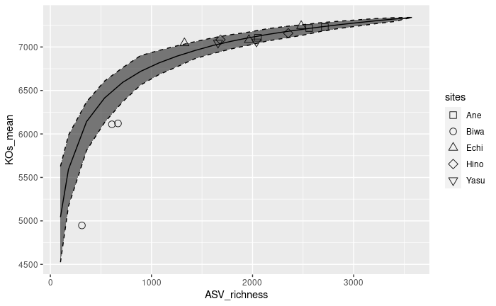

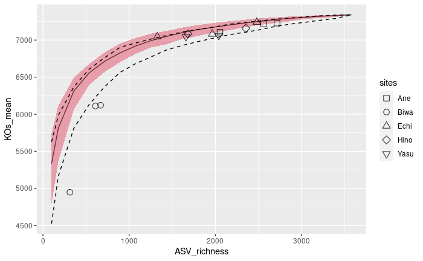

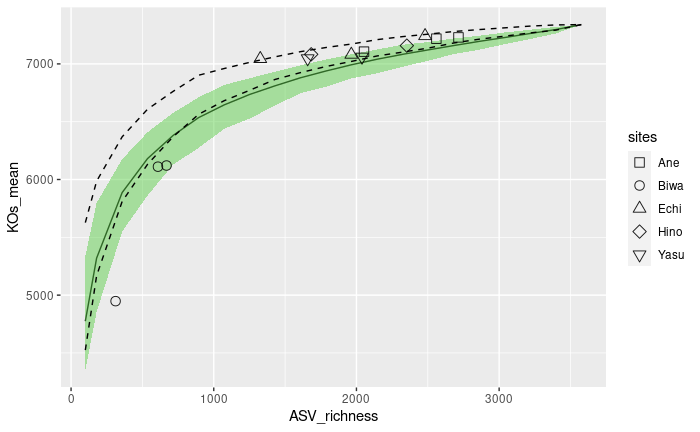

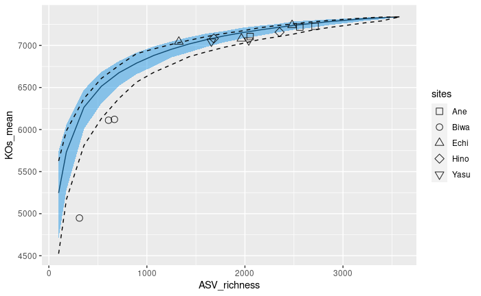

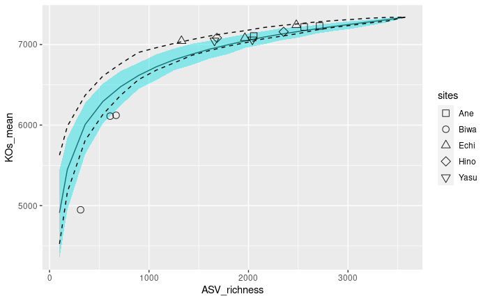

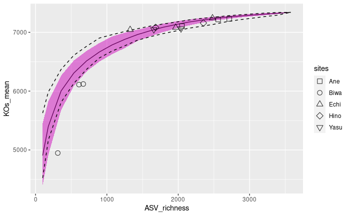

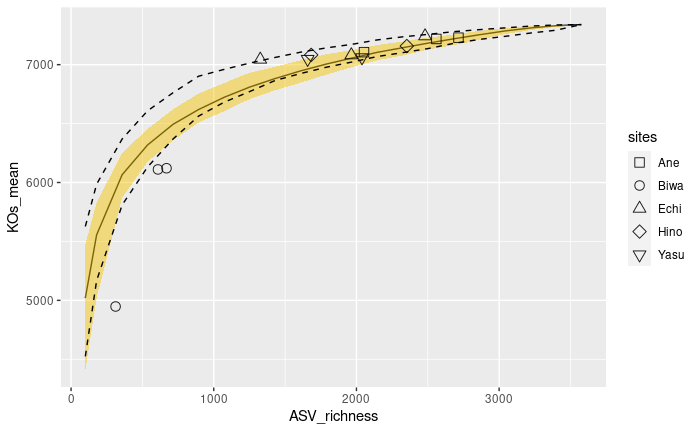

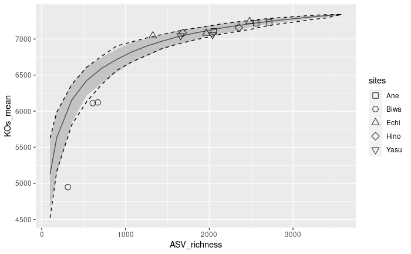

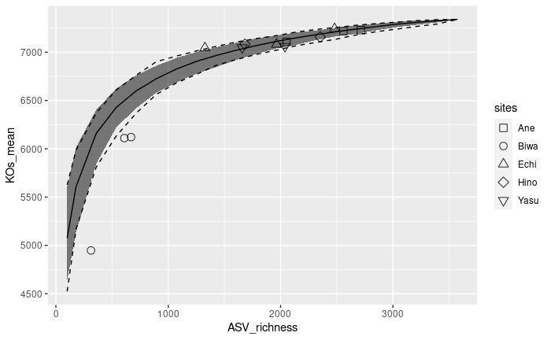

```r
meta_plot_j <- list()
for(j in 1:9) {
  meta_plot <- ggplot(data = meta_sim[[j]]) + geom_line(aes(x = ASV_richness, y = KOs_mean))
  meta_plot <- meta_plot + geom_ribbon(aes(x = ASV_richness, ymin = KOs_025, ymax = KOs_975), fill = j, alpha = 0.5)

  meta_plot <- meta_plot + geom_line(data = meta_sim[[1]], aes(x = ASV_richness, y = KOs_025), linetype = "dashed") #random range
  meta_plot <- meta_plot + geom_line(data = meta_sim[[1]], aes(x = ASV_richness, y = KOs_975), linetype = "dashed") #random range

  meta_plot <- meta_plot + geom_point(data = richness_MF, aes(x = ASV_richness, y = MF_G, shape = richness_MF$location), size = 3, alpha = 0.9) + labs(shape = "sites") + scale_shape_manual(values = c(0, 1, 2, 5, 6))
  meta_plot_j[[j]] <- meta_plot
}

for(j in 1: 9){
  plot(meta_plot_j[[j]])
}
```

#### [6.4.2] All scenarios together

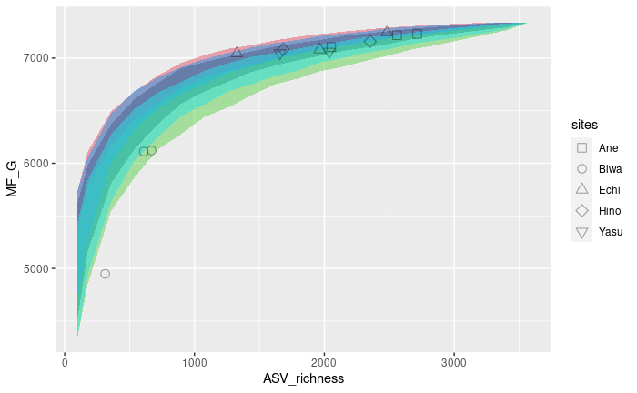

```r
meta_sim_all <- NULL
for(j in 1:9) {
  meta_sim_all <- rbind.data.frame(meta_sim_all, meta_sim[[j]])
}

#ribbon plot
meta_plot_all <- ggplot(data = meta_sim_all) #+ geom_line(aes(x = ASV_richness, y = KOs_mean, group = s, color = s))
for(j in 1:5) {
  start <- 1 + 21*(j - 1)
  end <- 21*j
  meta_plot_all <- meta_plot_all + geom_ribbon(data = meta_sim_all[start:end, ], aes(x = ASV_richness, ymin = KOs_025, ymax = KOs_975), fill = j, alpha = 0.5)
}
meta_plot_all <- meta_plot_all + geom_point(data = richness_MF, aes(x = ASV_richness, y = MF_G, shape = richness_MF$location), size = 3, alpha = 0.4) + labs(shape = "sites") + scale_shape_manual(values = c(0, 1, 2, 5, 6))
plot(meta_plot_all)
```

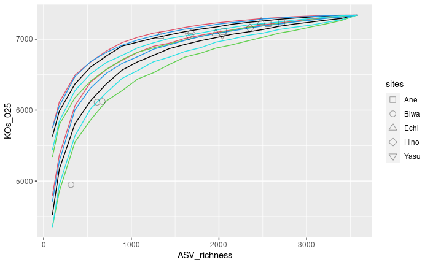

```r
#line plot
meta_plot_all <- ggplot(data = meta_sim_all) #+ geom_line(aes(x = ASV_richness, y = KOs_mean, group = s, color = s))
for(j in 1:5) {
  start <- 1 + 21*(j - 1)
  end <- 21*j
  meta_plot_all <- meta_plot_all + geom_line(data = meta_sim_all[start:end, ], aes(x = ASV_richness, y = KOs_025), color = j)
  meta_plot_all <- meta_plot_all + geom_line(data = meta_sim_all[start:end, ], aes(x = ASV_richness, y = KOs_975), color = j)
}
meta_plot_all <- meta_plot_all + geom_point(data = richness_MF, aes(x = ASV_richness, y = MF_G, shape = richness_MF$location), size = 3, alpha = 0.4) + labs(shape = "sites") + scale_shape_manual(values = c(0, 1, 2, 5, 6))
plot(meta_plot_all)
```

## [7] For Supporting Information

### [7.1] Correlation between KO-based functional traits

Cite: Why are some microbes more ubiquitous than others? Predicting the habitat breadth of soil bacteria, Ecology Letters, (2014) 17: 794–802 doi: 10.1111/ele.12282

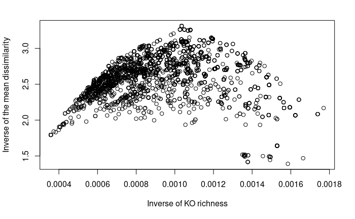

```r
plot(survival_rate_mod$F4 ~ survival_rate_mod$F2,
     xlab = "Inverse of KO richness",
     ylab = "Inverse of the mean dissimilarity"
     )
```

```r
plot(log10(survival_rate_mod$A1) ~ survival_rate_mod$F1,
     xlab = "KO richness",
     ylab = "log10(mean abundance)"
     )
f1_a1_model <- lm(log10(A1) ~ F1, data = survival_rate_mod)
summary(f1_a1_model)
```

```
Call:
lm(formula = log10(A1) ~ F1, data = survival_rate_mod)

Residuals:
     Min       1Q   Median       3Q      Max
-2.57323 -0.38115  0.02451  0.41292  2.93730

Coefficients:
             Estimate Std. Error t value Pr(>|t|)
(Intercept) 2.171e+00  4.105e-02    52.9   <2e-16 ***
F1          4.611e-04  3.468e-05    13.3   <2e-16 ***
---
Signif. codes:  0 ‘***’ 0.001 ‘**’ 0.01 ‘*’ 0.05 ‘.’ 0.1 ‘ ’ 1

Residual standard error: 0.6916 on 3574 degrees of freedom
Multiple R-squared:  0.04715,   Adjusted R-squared:  0.04688
F-statistic: 176.9 on 1 and 3574 DF,  p-value: < 2.2e-16
```

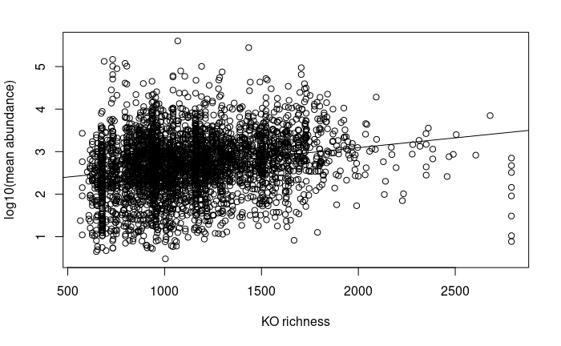

```r
abline(f1_a1_model)
```

```r
plot(survival_rate_mod$A3 ~ survival_rate_mod$F1,
     xlab = "KO richness",
     ylab = "No. of occurrence")

f1_a3_model <- lm(A3 ~ F1, data = survival_rate_mod)
summary(f1_a3_model)
```

```
Call:
lm(formula = A3 ~ F1, data = survival_rate_mod)

Residuals:
    Min      1Q  Median      3Q     Max
-8.6984 -2.0013 -0.0598  1.9386  7.5665

Coefficients:
             Estimate Std. Error t value Pr(>|t|)
(Intercept) 3.9165322  0.1580728   24.78   <2e-16 ***
F1          0.0020724  0.0001335   15.52   <2e-16 ***
---
Signif. codes:  0 ‘***’ 0.001 ‘**’ 0.01 ‘*’ 0.05 ‘.’ 0.1 ‘ ’ 1

Residual standard error: 2.663 on 3574 degrees of freedom
Multiple R-squared:  0.06313,   Adjusted R-squared:  0.06286
F-statistic: 240.8 on 1 and 3574 DF,  p-value: < 2.2e-16
```

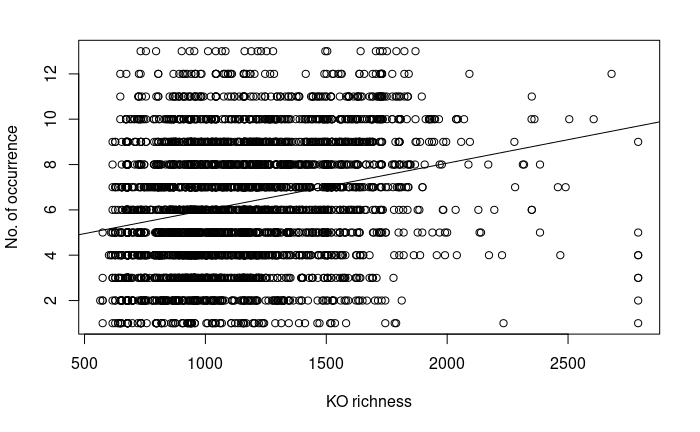

```r
abline(f1_a3_model)
```

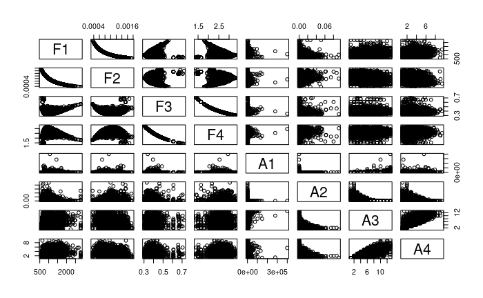

```r
plot(survival_rate_mod[, -1])
```

### [7.2] Another method to calculate functionally uniqueness

Based on the # of KOs that are not shared with all other ASVs

```r
uniqueKO <- numeric(length(stand_ASV_com_binarized[, 1]))
for(j in 1: length(stand_ASV_com_binarized[, 1])) {
  uniqueKO[j] <- sum(KO_com_binarized[j, ] == 1 & apply(KO_com_binarized[-j, ], 2, sum) == 0)
}
```

```r
sum(uniqueKO > 0)
```

```
[1] 127
```

```r
max(uniqueKO)
```

```
[1] 16
```

### [7.3] Direct fitting of power-law regression to the all data

This could be directly compared to Fig.3 in Ruhl et al. 2022

```r
for_SI_model <- lm(log10(MF_G) ~ log10(ASV_richness), data = richness_MF)
summary(for_SI_model)
```

```
Call:
lm(formula = log10(MF_G) ~ log10(ASV_richness), data = richness_MF)

Residuals:
      Min        1Q    Median        3Q       Max
-0.029250 -0.007767 -0.001558  0.010693  0.024683

Coefficients:
                    Estimate Std. Error t value Pr(>|t|)
(Intercept)          3.32892    0.04737   70.28 6.01e-16 ***
log10(ASV_richness)  0.15827    0.01489   10.63 4.00e-07 ***
---
Signif. codes:  0 ‘***’ 0.001 ‘**’ 0.01 ‘*’ 0.05 ‘.’ 0.1 ‘ ’ 1

Residual standard error: 0.01492 on 11 degrees of freedom
Multiple R-squared:  0.9113,    Adjusted R-squared:  0.9032
F-statistic:   113 on 1 and 11 DF,  p-value: 4.005e-07
```

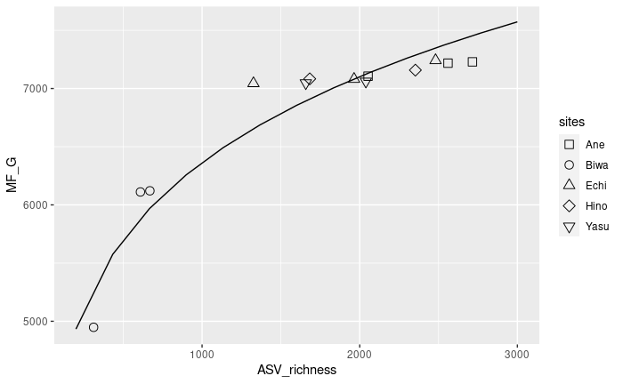

```r
#add data from prediction
richness_MF$asv_richness2 = seq(200, 3000, length.out = 13)
richness_MF$predicted2 = (10^for_SI_model$coefficients[1])*richness_MF$asv_richness2^for_SI_model$coefficients[2]
power_plot <- ggplot(data = richness_MF) + geom_point(aes(x = ASV_richness, y = MF_G, shape = richness_MF$location), size = 3) + labs(shape = "sites") + scale_shape_manual(values = c(0, 1, 2, 5, 6))
power_plot <- power_plot + geom_line(aes(x = asv_richness2, y = predicted2))
plot(power_plot)
```